# 正規分布のパラメータをギブスサンプリングで推定する

pb10005

2022/2/20

## 1 前提知識

### 1.1 ベイズの定理

条件付き確率密度関数について下式の関係が成り立ち、これをベイズの定理と呼ぶ。
$$\begin{eqnarray}
p(\boldsymbol{\theta}|\boldsymbol{y}) &=& \frac{p(\boldsymbol\theta)p(\boldsymbol{y}|\boldsymbol{\theta})}{p(\boldsymbol{y})}
\end{eqnarray}$$

$p(\boldsymbol\theta)$を事前分布(prior distribution)、$p(\boldsymbol{\theta}|\boldsymbol{y})$を事後分布(posterior distribution)、$p(\boldsymbol{y}|\boldsymbol{\theta})$を尤度(likelihood)という。事後分布を解析的に評価できることは稀であり、定数部分を除いたカーネルと呼ばれる形で表すことが多い。

$$p(\boldsymbol{\theta}|\boldsymbol{y}) \propto p(\boldsymbol\theta)p(\boldsymbol{y}|\boldsymbol{\theta})$$

ベイズの定理は、「何らかの事前情報に基づいて与えられた事前分布、および観測データがあれば、パラメータを確率分布として推定できる」と解釈することができる。

### 1.2 共役事前分布

一般に事後分布を求めることは容易ではないが、事前分布と尤度の組み合わせをうまく選べば、事後分布が事前分布と同じクラスの確率分布になることがある。このような事前分布を共役事前分布と呼ぶ。代表的な共役事前分布にはベルヌーイ分布に対するベータ分布、ポアソン分布に対するガンマ分布などがある。

### 1.3 ギブスサンプリング

他のすべてのパラメータを所与としたときの条件付確率分布を完全条件付き分布という。ギブスサンプリングは、パラメータ$\theta$の完全条件付分布が既知で、かつサンプリングが容易である場合に使用可能なサンプリングアルゴリズムである。$k$次元のパラメータに対する完全条件付分布を以下のように表現する。

$$\{h(\theta_{j}^{(i)}|\theta_{-j}^{(i-1)} ), j =1,2,3,...,k\}$$

ここで$\theta_{-j}^{(i-1)}$は以下のとおり定義される。

$$\theta_{-j}^{(i-1)} \equiv \theta_{1}^{(i)}, ...,\theta_{j-1}^{(i)}, \theta_{j+1}^{(i-1)}, ..., \theta_{k}^{(i-1)}$$

各パラメータの系列$\{\boldsymbol{\theta}^{(i)}, i=1,2,...,N\}$はマルコフ連鎖である。

#### ギブスサンプリングの手順

1. 初期値$\{\theta_{j}^{(0)}, j =1,2,3,...,k\}$を設定する
2. 以下をN回繰り返す。

$$\left\{
\begin{array}{l}
\theta_{1}^{(i)} \sim h(\theta_{1}^{(i)}|\theta_{-1}^{(i-1)} ) \\
\vdots \\
\theta_{j}^{(i)} \sim h(\theta_{j}^{(i)}|\theta_{-j}^{(i-1)} ) \\
\vdots \\
\theta_{k}^{(i)} \sim h(\theta_{k}^{(i)}|\theta_{-k}^{(i-1)} )
\end{array}
\right.$$

こうして得られた各パラメータの系列$\{\boldsymbol{\theta}^{(i)}, i=1,2,...,N\}$のヒストグラム(経験分布)が、同時分布$h(\boldsymbol{\theta})$に収束する。

## 2 ギブスサンプリングによる正規分布のパラメータ推定

正規分布 $N(\mu, \sigma^2)$に従う $N$個の独立な観測 $y_i \in \boldsymbol{y}, i=1,2, ... , N$が与えられたとする。このとき未知のパラメータ$\mu, \sigma^2$をギブスサンプリングにより推定したい。

### 2.1 尤度の計算

観測$\boldsymbol{y}$の尤度は以下の式で表すことができる。

$$\begin{eqnarray}
p(\boldsymbol{y}|\mu, \sigma^2) &=& \prod_{i=1}^{N}\frac{1}{\sqrt{2\pi\sigma^2}} \mathrm{exp} \left[-\frac{1}{2\sigma^2}(y_i - \mu)^2\right] \\
&=& \left(\frac{1}{\sqrt{2\pi\sigma^2}}\right)^N \mathrm{exp} \left[-\frac{1}{2\sigma^2}\sum_{i=1}^{N}{(y_i - \mu)^2}\right]
\end{eqnarray}$$

### 2.2 $\mu$のサンプリング

$\sigma^2$を所与としたときの$\mu$の事後分布のカーネルを求める。$\mu$の事前分布を$N(\mu_0, \sigma_0^2)$とすると、

$$\begin{eqnarray}
p(\mu|\boldsymbol{y}) &\propto& p(\mu)p(\boldsymbol{y}|\mu) \\
&=& \frac{1}{\sqrt{2\pi\sigma_0^2}} \mathrm{exp}\left[-\frac{(\mu - \mu_0)^2}{2\sigma_0^2}\right] \left(\frac{1}{\sqrt{2\pi\sigma^2}}\right)^N \mathrm{exp} \left[-\frac{1}{2\sigma^2}\sum_{i=1}^{N}{(y_i - \mu)^2}\right] \\
&\propto& \mathrm{exp}\left[ -\frac{(\mu - \mu_0)^2}{2\sigma_0^2} - \frac{n(\mu - \bar{y})^2}{2\sigma^2}\right] \\
&\propto& \mathrm{exp} \left[-\left(\mu - \frac{\frac{\mu_0}{\sigma_0^2} + \frac{n\bar{y}}{\sigma^2}}{\frac{1}{\sigma_0^2} + \frac{n}{\sigma^2}}\right)^2 / \left(2 \cdot \frac{1}{\frac{1}{\sigma_0^2} + \frac{n}{\sigma^2}}\right)\right]
\end{eqnarray}$$

より、$\mu$の事後分布は正規分布 $N\left(\frac{\frac{\mu_0}{\sigma_0^2} + \frac{n\bar{y}}{\sigma^2}}{\frac{1}{\sigma_0^2} + \frac{n}{\sigma^2}}, \frac{1}{\frac{1}{\sigma_0^2} + \frac{n}{\sigma^2}}\right)$ に従うことがわかる。  
※3行目の変形で$\sum_{i=1}^N(y_i - \mu)^2 = n\mu^2 - 2\mu\sum_{i=1}^N{y_i} + const.$を用いた。  
※4行目の変形で$a(x-b)^2+c(x-d)^2 = (a+c)\left(x - \frac{ab+cd}{a+c}\right)^2+const.$を用いた。

### 2.3 $\sigma^2$のサンプリング

$\mu$を所与としたときの$\sigma^2$の事後分布のカーネルを求める。$\tau = \frac{1}{\sigma^2}$と変換すると、ガンマ分布$Ga(a, b)$が共役事前分布となることが知られている。

$$\begin{eqnarray}
p(\tau|\boldsymbol{y}) &\propto& p(\tau)p(\boldsymbol{y}|\tau) \\
&=& \frac{1}{\Gamma(a)}\left(\frac{\tau}{b}\right)^{a-1}\frac{1}{b}\mathrm{exp}\left(-\frac{\tau}{b}\right)\left(\frac{\sqrt{\tau}}{\sqrt{2\pi}}\right)^N \mathrm{exp} \left[-\frac{\tau}{2}\sum_{i=1}^{N}{(y_i - \mu)^2}\right] \\
&\propto& \tau^{a-1+\frac{N}{2}} \mathrm{exp}\left[-\tau \left(\frac{1}{b} + \frac{1}{2}\sum_{i=1}^N (y_i - \mu)^2\right) \right]
\end{eqnarray}$$

より、$\tau$の条件付事後分布は以下のように表すことができる。
$$p(\tau|\boldsymbol{y}, \mu) \sim Ga\left(a+\frac{N}{2},\frac{1}{\frac{1}{b} + \frac{1}{2}\sum_{i=1}^{N}(y_i - \mu)^2}\right)$$

### 2.4 Rによる実装

参考文献:照井伸彦 (2010)

#### 観測の作成

```r
# 平均10, 標準偏差3の正規乱数を500個発生させる
y <- rnorm(n = 500, mean = 10, sd = 3)
my <- mean(y)
n <- length(y)
```

#### 初期化

```r
# 繰り返し回数を設定
iterations <- 10000
theta <- matrix(nrow = iterations, ncol = 2)

# 事前分布のパラメータを設定
m0 <- 0
s0 <- 1
a0 <- 0
b0 <- 0.01

# 事後分布のパラメータを初期化
cur.mu <- 0
cur.tau <- 1
cur.s <- sqrt(1/cur.tau)
```

#### サンプリング

```r
for (t in 1:iterations) {
  # muのサンプリング
  w <- s0^2 / (cur.s^2/n + s0^2)
  m <- w * my + (1-w) * m0
  s <- sqrt(w + cur.s^2 / n)
  cur.mu <- rnorm(1, m, s)

  # sのサンプリング
  a <- a0 + 0.5 * n
  b <- b0 + 0.5 * sum((y - cur.mu)^2)
  cur.tau <- rgamma(1, a, b)
  cur.s <- sqrt(1 / cur.tau)

  # t回目の推定値
  theta[t,] <- c(cur.mu, cur.s)
}
```

#### サンプリング系列の可視化

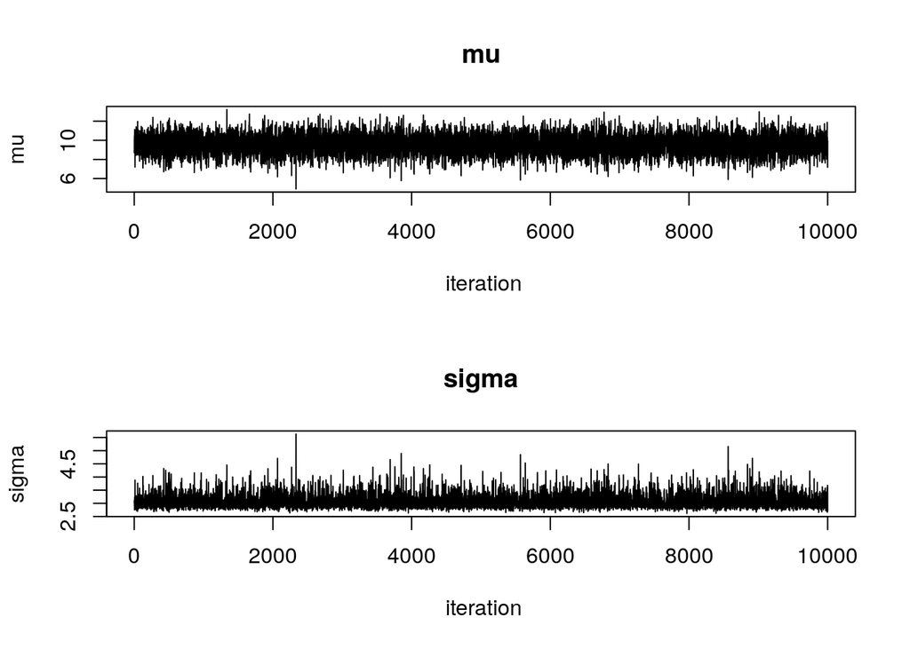

```r
op <- par(mfrow=c(2,1))
p <- 1:iterations
plot(p, theta[,1], type="l", main="mu", xlab=" iteration", ylab="mu", lty=1, lwd=1);plot(p, theta[,2], type="l", main="sigma", xlab=" iteration", ylab="sigma", lty=1, lwd=1);
```

#### ヒストグラム

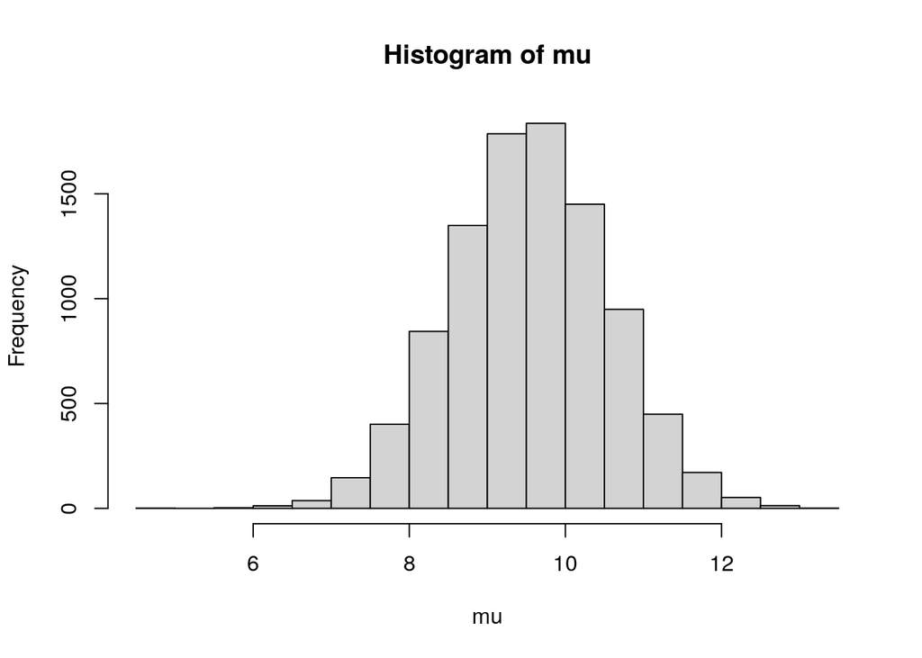

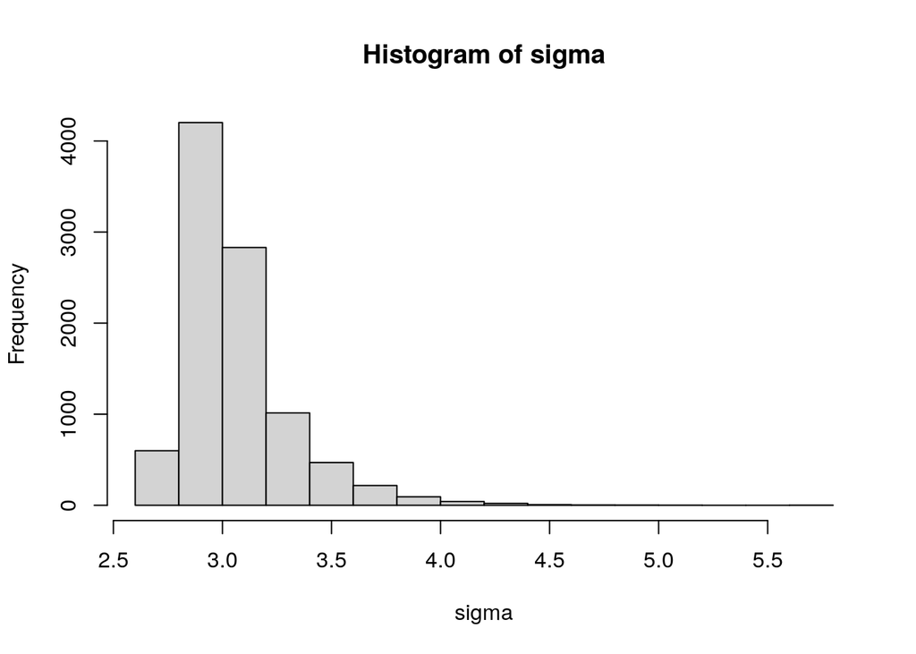

```r
hist(theta[501:iterations,1], breaks="Sturges", main="Histogram of mu", xlab="mu");hist(theta[501:iterations,2], breaks="Sturges", main="Histogram of sigma", xlab="sigma")
```

#### パラメータの推定値

```r
print(c(mean(theta[2001:iterations,1]),mean(theta[2001:iterations,2])))
```

```
## [1] 9.541092 3.058884
```

## 参考文献

照井伸彦. 2010. *Rによるベイズ統計分析*.